# Gradient Boosted Models Using Simulated Data

IDEXX People Analytics

# This code details how the gbm package works for a bernoulli distributed response.

- A synthetic rare event dataset is created
  - N=1010 (10 events; 1,000 non-events); y<sub>i</sub> $\in$ {0, 1}
  - The event rate is just below 1%
  - Three continuous variables are created: N1, N2, N3 each with different distributions depending on event class
  - For non-events:
    $$N1 \sim \mathcal{N}(\mu = 15,\,\sigma^{2} = 1)$$
    $$N2 \sim \mathcal{N}(\mu = 199,\,\sigma^{2} = 10)$$
    $$N2 \sim \mathcal{N}(\mu = 2510,\,\sigma^{2} = 50)$$
  - For events:
    $$N1 \sim \mathcal{N}(\mu = 15,\,\sigma^{2} = 1)$$
    $$N2 \sim \mathcal{N}(\mu = 200,\,\sigma^{2} = 10)$$
    $$N2 \sim \mathcal{N}(\mu = 2500,\,\sigma^{2} = 50)$$

```r
#Set random generator seed
set.seed(456)

#Simulate non-event data from multi-variate normal distribution
Sim.Norm.K1 <- mvrnorm(n = 1000,
                       mu=c(15, 199, 2510),
                       Sigma = matrix(c(1, 0, 0, 0, 10, 0, 0, 0, 50), nrow = 3, ncol = 3),
                       tol = 1e-6,
                       empirical = FALSE)
Sim.Norm.K1.class <- cbind.data.frame(0, Sim.Norm.K1)
colnames(Sim.Norm.K1.class) <- c("Class","N1","N2","N3")

#Simulate event data from multi-variate normal distribution
Sim.Norm.K2 <- mvrnorm(n = 10,
                       mu=c(15, 200, 2500),
                       Sigma = matrix(c(1, 0, 0, 0, 10, 0, 0, 0, 50), nrow = 3, ncol = 3),
                       tol = 1e-6,
                       empirical = FALSE)
Sim.Norm.K2.class <- cbind.data.frame(1, Sim.Norm.K2)
colnames(Sim.Norm.K2.class) <- c("Class","N1","N2","N3")

#Smoosh it all together in one data frame
Rare.Data.Frame <- rbind.data.frame(Sim.Norm.K1.class, Sim.Norm.K2.class)
```

# Three dimensional plot of feature space

Data points for rare events are in red.

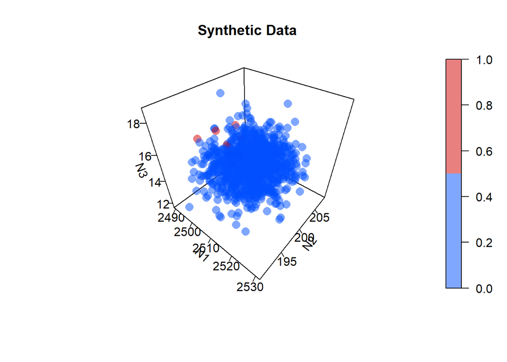

# Density plot for each variable

Events in blue; non-events in grey.

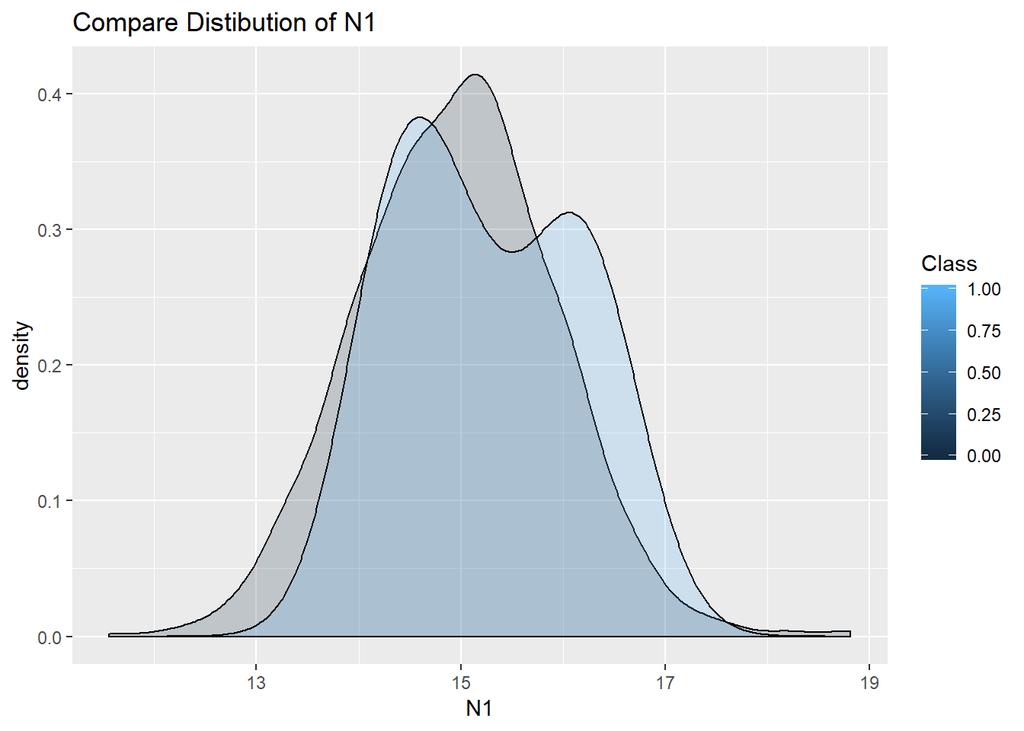

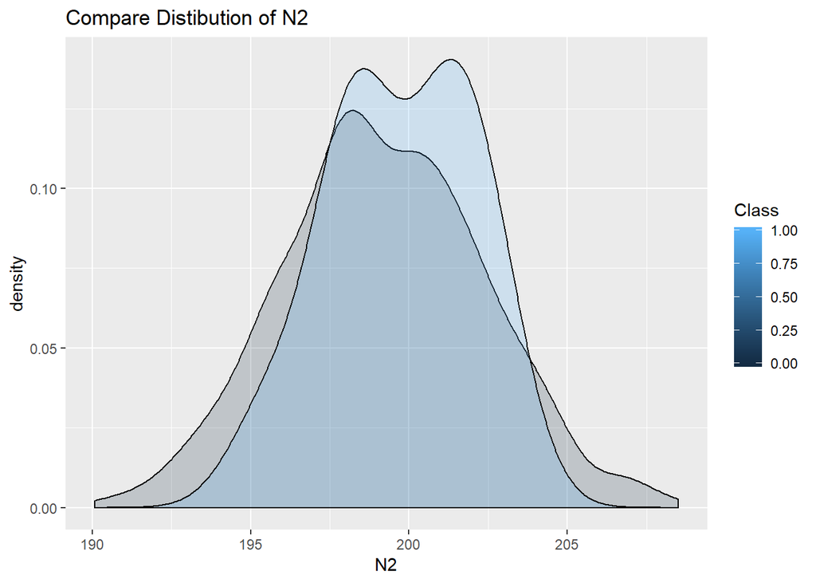

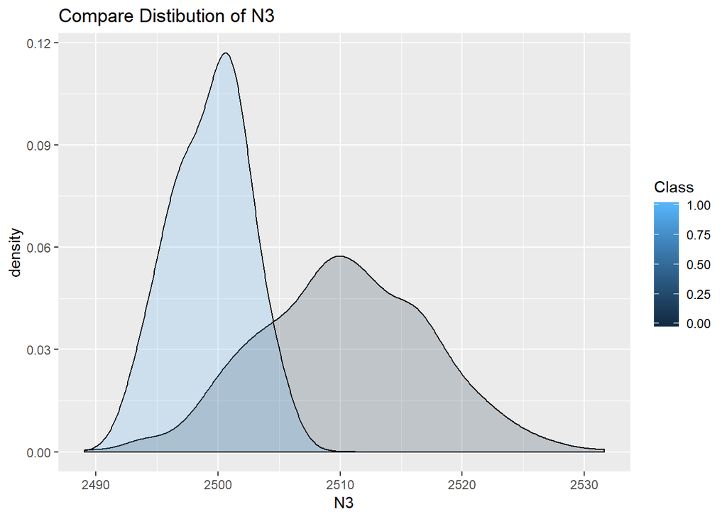

The densities for variables N1 and N2 are substantially overlapping for the two classes. The distribution of N3 for events versus non-events does have some overlap, but there is a clear difference in the distribution for the two classes. This variable should be the most predictive.

# GBM - code used to fit model

```r
#Set random generator seed
set.seed(123)
Bern.gbm <-     gbm(Class ~  ., #Predict class using all other variables in the data frame
                    data=Rare.Data.Frame,
                    distribution = "bernoulli",
                    var.monotone = NULL,
                    n.trees = 100, #per Friedman et al: setting shrinkage low & iterations high
                    interaction.depth = 2, #Number of splits (2) is usually insufficient and > 10 rarely needed)
                    n.minobsinnode = 1, #Minimum number of observations per node...this should be higher in practice
                    shrinkage = 0.005, #per Friedman et al: setting shrinkage low & iterations high
                    bag.fraction = 1, #1 means NO subsampling (for regression 0.5<=bag.fraction<=0.8 and for classification > 0.8 or 1)
                    cv.folds=, #in practice 3 to 5 for selection optimal number of trees to grow
                    keep.data = TRUE,
                    verbose = FALSE,
                    class.stratify.cv=,
                    n.cores = 4) #quad core processing
```

# Variable importance weights and names of elements stored in Bern.gbm object

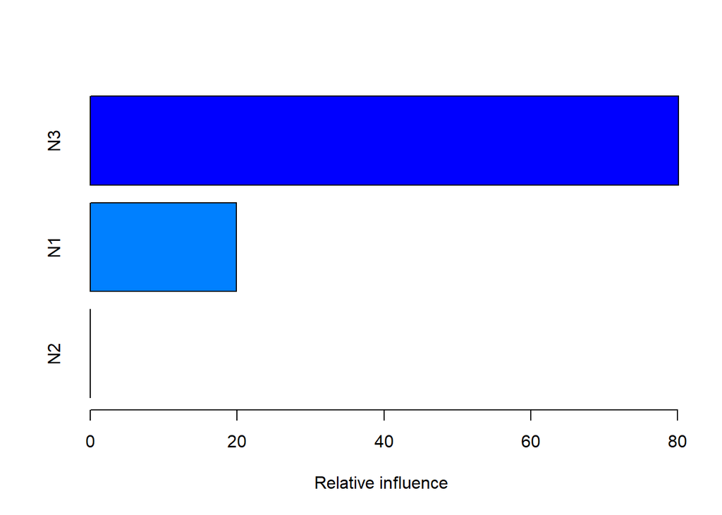

```
##    var  rel.inf
## N3  N3 80.12194
## N1  N1 19.87806
## N2  N2  0.00000
```

```
##  [1] "initF"             "fit"               "train.error"
##  [4] "valid.error"       "oobag.improve"     "trees"
##  [7] "c.splits"          "bag.fraction"      "distribution"
## [10] "interaction.depth" "n.minobsinnode"    "num.classes"
## [13] "n.trees"           "nTrain"            "train.fraction"
## [16] "response.name"     "shrinkage"         "var.levels"
## [19] "var.monotone"      "var.names"         "var.type"
## [22] "verbose"           "data"              "Terms"
## [25] "cv.folds"          "call"              "m"
```